# Multivariate Analyses

Mathew Rees

April 2023

In this notebook, I want to highlight some common methods to explore a dataset, in univariate and multivariate aspects. This first step of exploring the data is often referred to as Exploratory Data Analysis (or EDA for short) and is one of the most vital things we need to do before taking anything further.

We will place this work in a taxonomic context, where it might be useful if we want to perform some morphometric analyses. This can be at any level, from populations of the same species, to species complexes, all the way to entire clades.

As a bit of background, I would like to revisit the schools of Phenetics vs. Cladistics, focusing on the methodology that Phenetics has left us.

First let’s load the libraries necessary for this session.

You can simply click on the `code` button to unfold the code, and click on the small “Copy” icon to copy all the code from a cell.

```r
# If you haven't already installed these packages, you can uncomment the following lines

#packages <- c("tidyverse", "mclust", "NbClust", "ade4", "factoextra", "dendextend", "PerformanceAnalytics", "rpart", "rpart.plot", "MASS", "colorspace", "FD", "vegan", "missMDA", "ggrepel")

#new.packages <- packages[!(packages %in% installed.packages()[,"Package"])]

#if(length(new.packages)) install.packages(new.packages)

library(tidyverse)
library(mclust)
library(NbClust)
library(ade4)
library(factoextra)
library(dendextend)
library(PerformanceAnalytics)
library(rpart)
library(rpart.plot)
library(MASS)
library(colorspace)
library(FD)
library(vegan)
library(missMDA)
library(ggrepel)
```

# 1 EDA

We will be working with Ronald Fisher’s classic iris dataset than comes inbuilt in R. So no need to download anything.

First, let’s have a look at the data.

```r
# str() stands for 'structure'
str(iris)
```

```
'data.frame':   150 obs. of  5 variables:
 $ Sepal.Length: num  5.1 4.9 4.7 4.6 5 5.4 4.6 5 4.4 4.9 ...
 $ Sepal.Width : num  3.5 3 3.2 3.1 3.6 3.9 3.4 3.4 2.9 3.1 ...
 $ Petal.Length: num  1.4 1.4 1.3 1.5 1.4 1.7 1.4 1.5 1.4 1.5 ...
 $ Petal.Width : num  0.2 0.2 0.2 0.2 0.2 0.4 0.3 0.2 0.2 0.1 ...
 $ Species     : Factor w/ 3 levels "setosa","versicolor",..: 1 1 1 1 1 1 1 1 1 1 ...
```

Great, so we have a dataframe with 5 columns and 150 rows.

The dataset comes with a handy `Species` column, which indicates which row of data belongs to which species. In real life we might not have that information.

Let’s take a quick peek at the first rows of our data just to make sure we can visualise the dataframe.

```r
head(iris)
```

|  | Sepal.Length | Sepal.Width | Petal.Length | Petal.Width | Species |
| --- | --- | --- | --- | --- | --- |
| 1 | 5.1 | 3.5 | 1.4 | 0.2 | setosa |
| 2 | 4.9 | 3.0 | 1.4 | 0.2 | setosa |
| 3 | 4.7 | 3.2 | 1.3 | 0.2 | setosa |
| 4 | 4.6 | 3.1 | 1.5 | 0.2 | setosa |
| 5 | 5.0 | 3.6 | 1.4 | 0.2 | setosa |
| 6 | 5.4 | 3.9 | 1.7 | 0.4 | setosa |

We can get a summary of each of these variables

```r
summary(iris)
```

```
  Sepal.Length    Sepal.Width     Petal.Length
 Min.   :4.300   Min.   :2.000   Min.   :1.000
 1st Qu.:5.100   1st Qu.:2.800   1st Qu.:1.600
 Median :5.800   Median :3.000   Median :4.350
 Mean   :5.843   Mean   :3.057   Mean   :3.758
 3rd Qu.:6.400   3rd Qu.:3.300   3rd Qu.:5.100
 Max.   :7.900   Max.   :4.400   Max.   :6.900
  Petal.Width          Species
 Min.   :0.100   setosa    :50
 1st Qu.:0.300   versicolor:50
 Median :1.300   virginica :50
 Mean   :1.199
 3rd Qu.:1.800
 Max.   :2.500
```

This gives us the minimum, first quartile, median, mean, 3rd quartile and maximum values for each of the variables in our data frame. You can see that, in the last column, there are 50 measurements for each of the 3 species.

We can visualise this with box plots.

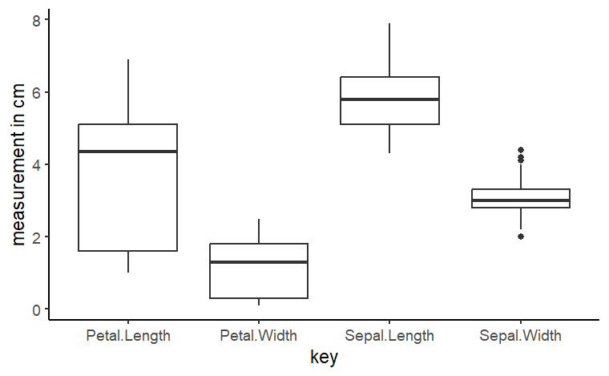

```r
iris %>%
  dplyr::select(-Species) %>%
  gather() %>%
  ggplot() +
  geom_boxplot(aes(x=key, y=value)) +
  ylab("measurement in cm") +
  theme_classic()
```

So let’s get a sense of how these three species look like in terms of their characters. We will plot each character one by one and look at their distribution and colour code this according to which species we are looking at.

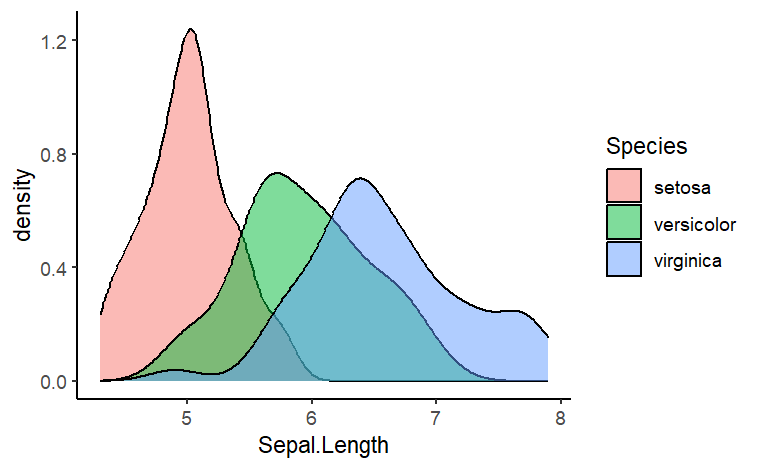

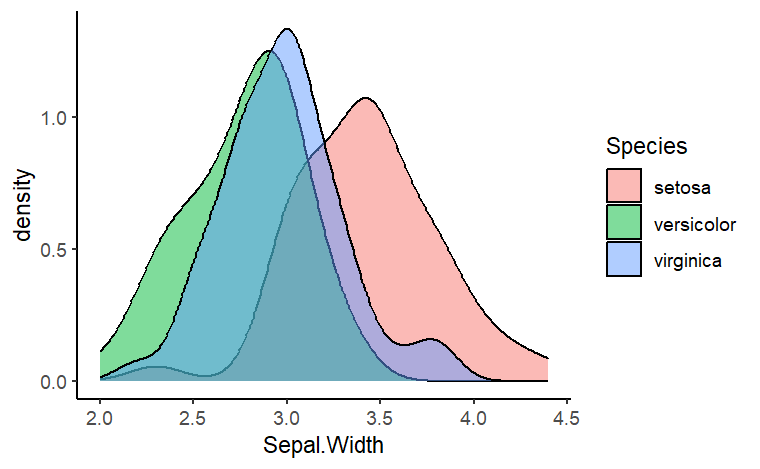

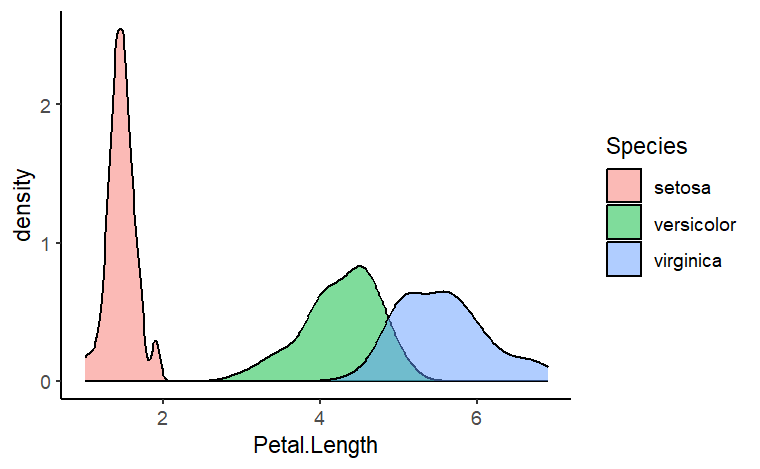

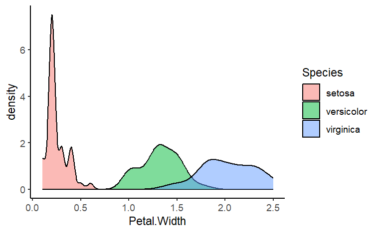

```r
for (i in list("Sepal.Length", "Sepal.Width", "Petal.Length", "Petal.Width")) {

p<-ggplot(iris, aes_string(x=i)) +
  geom_density(aes(fill=Species), alpha = 0.5) +
  theme_classic()

print(p)

}
```

Interesting. Some of the characters show more “gaps” than others. For example, Petal.Length and Petal.Width clearly show *I.setosa* as being separate from the two other species. It generally has a smaller petal length and petal width.

In the early days, “gaps” were a central tenant of numerical taxonomy, also known as phenetics. If two groups (Species, Genus, Family, or whatever taxon you chose) were to be separated, they had to display a “gap” in their characteristics.

For more info on Phenetics vs Cladistics, the work of Sneath and Sokal (1973) and Willi Hennig (1966 which is the english translated version of his 1950 work) are the foundation.

But for now, back to our data.

How are the variables related to each other? Are these variables correlated in any way ?

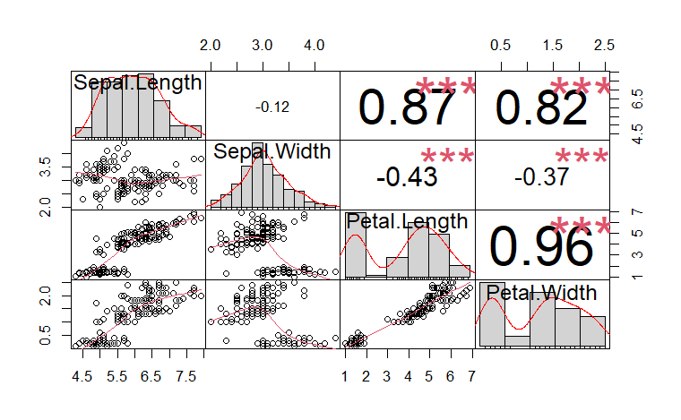

```r
chart.Correlation(iris[,-5]) # here, iris[,-5] means we are taking out the 5th column
```

Petal Length and Petal width seem to be highly correlated with each other.

Now we can make some scatter plots, looking at two characters plotted against each other.

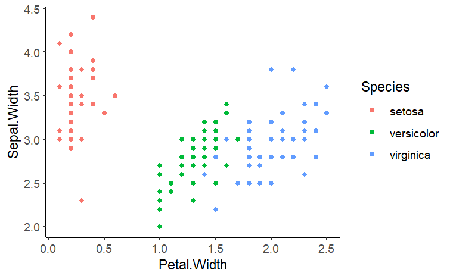

```r
ggplot(iris) +
  geom_point(aes(y=Sepal.Width, x=Petal.Width, col=Species)) +
  theme_classic()
```

This is a pretty nice one. We can see that when looking at sepal width vs petal width, *I.setosa* is clearly separate from the two other species.

But what if we didn’t have that `Species` information?

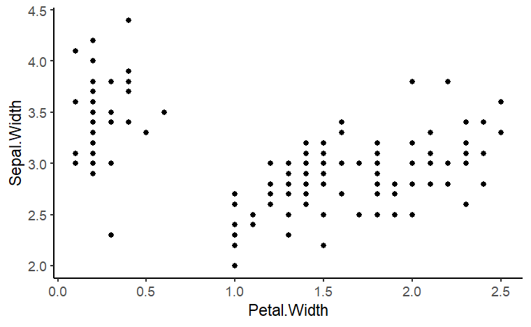

```r
ggplot(iris) +
  geom_point(aes(y=Sepal.Width, x=Petal.Width)) +
  theme_classic()
```

Would you still say there are three species? Or just two?

That’s where we will dive into the world of numerical taxonomy. Let’s get started!

# 2 Principle Component Analysis (PCA)

In the first scatter plot, we used only 2 characters, but what if we want to use all available characters? That would require us to be able to visualise the data in 4 dimension, given we have 4 variables.

If we had even more characters to analyze, you can quickly see how difficult this becomes.

We can do that by reducing the number of dimensions with an ordination, such as principal components analysis (PCA). More info on PCA in R [here](https://aedin.github.io/PCAworkshop/articles/b_PCA.html).

The first thing to understand is the concept of scaling our data. In most datasets, each variable is different either by the unit measured (eg, distance vs count) or by the scale of the unit (eg. 10cm vs 100 cm.)

We need to make sure all our variables are comparable to each other in terms of units and scale. In other words, we want to be able to compare apples with apples.

Let’s look at what this means with our data

```r
iris[,-5] %>% head()
```

|  | Sepal.Length | Sepal.Width | Petal.Length | Petal.Width |
| --- | --- | --- | --- | --- |
| 1 | 5.1 | 3.5 | 1.4 | 0.2 |
| 2 | 4.9 | 3.0 | 1.4 | 0.2 |
| 3 | 4.7 | 3.2 | 1.3 | 0.2 |
| 4 | 4.6 | 3.1 | 1.5 | 0.2 |
| 5 | 5.0 | 3.6 | 1.4 | 0.2 |
| 6 | 5.4 | 3.9 | 1.7 | 0.4 |

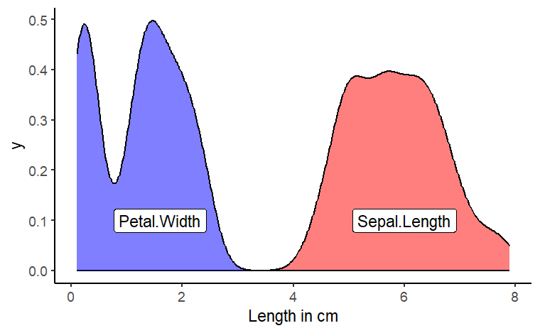

```r
ggplot(iris) +
  geom_density(aes(x=Sepal.Length), fill="red", alpha=0.5) +
  geom_label(aes(label = "Sepal.Length", x = 6, y=0.1)) +
  geom_density(aes(x=Petal.Width), fill="blue", alpha = 0.5) +
  geom_label(aes(label = "Petal.Width", x = 1.6, y=0.1)) +
  xlab("Length in cm") +
  theme_classic()
```

We know that all our measurements use the same unit, ie. cm. But we can see that the first column (Sepal.Length) has values that are much larger than the fourth column (Petal.Width).

It would be great if we could make these two distributions overlap.

Lets scale the data and have a look at the same first rows

```r
scaled.iris<-scale(iris[,-5]) %>% data.frame()
scaled.iris$Species <- iris$Species
head(scaled.iris)
```

|  | Sepal.Length | Sepal.Width | Petal.Length | Petal.Width | Species |
| --- | --- | --- | --- | --- | --- |
| 1 | -0.8976739 | 1.01560199 | -1.335752 | -1.311052 | setosa |
| 2 | -1.1392005 | -0.13153881 | -1.335752 | -1.311052 | setosa |
| 3 | -1.3807271 | 0.32731751 | -1.392399 | -1.311052 | setosa |
| 4 | -1.5014904 | 0.09788935 | -1.279104 | -1.311052 | setosa |
| 5 | -1.0184372 | 1.24503015 | -1.335752 | -1.311052 | setosa |
| 6 | -0.5353840 | 1.93331463 | -1.165809 | -1.048667 | setosa |

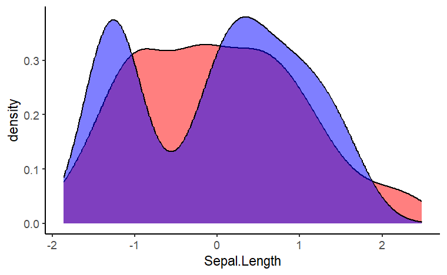

```r
ggplot(scaled.iris) +
  geom_density(aes(x=Sepal.Length), fill="red", alpha=0.5) +
  geom_density(aes(x=Petal.Width), fill="blue", alpha=0.5) +
  theme_classic()
```

We can see that `scale()` has preserved the shape of the data, but now we are able to compare the two variables because they are on the same scale. They have also been centered around 0.

For more info on scaling and transforming your data to fit a normal distribution, see [this great tutorial by Matus Seci](https://ourcodingclub.github.io/tutorials/data-scaling/).

Great, this is a prerequisite for running the PCA, all variables must be scaled and centered. Now we can continue with the analysis.

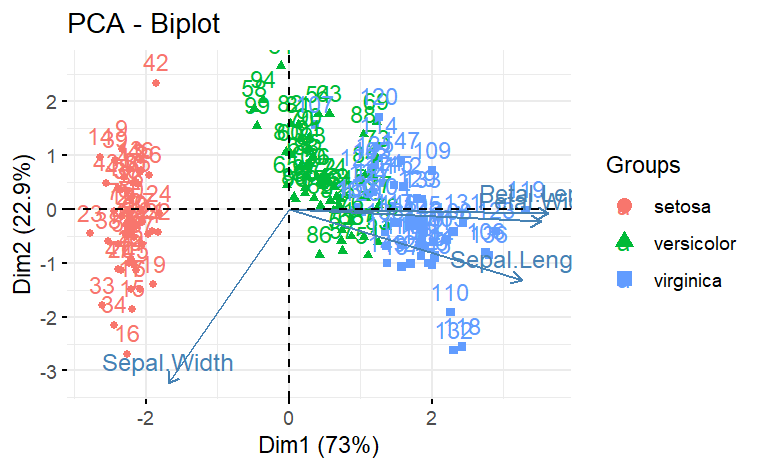

```r
## The dudi.pca function comes from the ade4 package
pca.iris<-dudi.pca(iris[,-5], nf = 2, scannf = F, center = T, scale = T) # Note here that I am using center = T and scale = T, which is the same as if i had used the new `scaled.iris` object

## Visualize the pca.iris object
fviz_pca(pca.iris, habillage=iris$Species)
```

Nice. we can see the three species plotted in multidimensional space. This looks a lot like the scatterplot that we made using just Sepal Width and Petal Width.

Again, we can see that *I.setosa* clusters nicely away from the two other species. But we can also see that separating *I.virginica* from *I.versicolor* is not that straight forward. They seem to overlap a little. If we didn’t have the `Species` label to help us decipher the plot, we might think there are only two groups.

The first axis explains 73% of the variation in the data and the second axis 22.9%. That’s quite good, it means that we are capturing a high amount of information (95.8% to be exact) from all the variables in our dataset by representing them on only 2 axes.

You can also see which variables contributed to which axes. For example Petal Length and Width contribute most to the first axis. Sepal Width contributes the most to the second axis.

Let’s check this out visually with a scree plot and a contribution plot

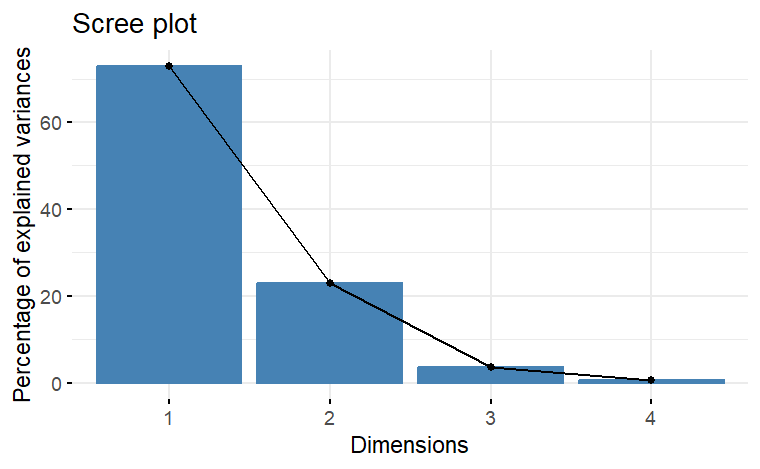

```r
fviz_eig(pca.iris)
```

```r
get_eig(pca.iris)
```

|  | eigenvalue | variance.percent | cumulative.variance.percent |
| --- | --- | --- | --- |
| Dim.1 | 2.91849782 | 72.9624454 | 72.96245 |
| Dim.2 | 0.91403047 | 22.8507618 | 95.81321 |
| Dim.3 | 0.14675688 | 3.6689219 | 99.48213 |
| Dim.4 | 0.02071484 | 0.5178709 | 100.00000 |

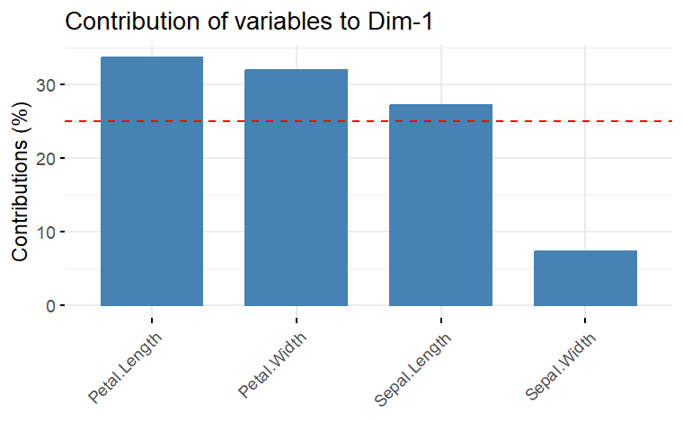

```r
fviz_contrib(pca.iris, "var", axes = 1)
```

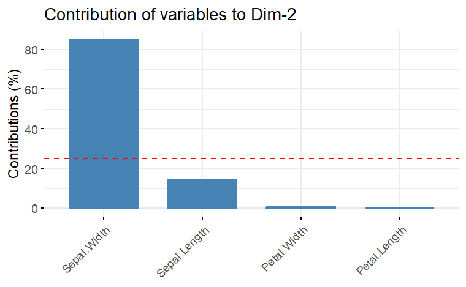

```r
fviz_contrib(pca.iris, "var", axes = 2)
```

The scree plot shows you the percentage of variance explained by each Principal Component. The contribution plot shows you the percentage contribution of each variable to that specific principal component.

# 3 Hill-Smith ordination

In the previous section, we saw that PCA is a powerful tool to combine lots of dimensions of our data into a small number of axes for us to visualise and analyse.

PCA only works with continuous data, but sometimes we might also have categorical data, like deciduous vs evergreen or woody vs herbaceous.

In this case, we cannot use PCA. Instead, we can use a very similar type of analysis such as Hill-Smith Analysis, or Multiple Factor Analysis. These methods allow us to combine both continuous and categorical data.

For the sake of demonstration, I will create a new column containing a factor and add it to our iris dataset.

```r
set.seed(123)
# Create a random categorical variable and make it a factor
iris$woodiness <- sample(c("woody", "herbaceous"), 150, replace = T) %>% as.factor()
# Run the ordination
iris.hillsmith <- dudi.hillsmith(iris[,-5], scannf = F, nf = 2)
```

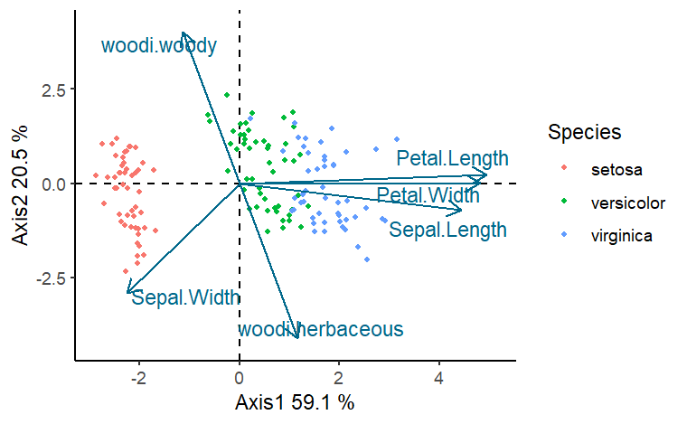

```r
ggplot(iris.hillsmith$li, aes(Axis1, Axis2)) +
    geom_hline(yintercept = 0, linetype="dashed") +
    geom_vline(xintercept = 0, linetype="dashed") +
    geom_point(aes(col=iris$Species),size=1) +
    geom_segment(data=iris.hillsmith$co, aes(x=0, y=0, xend=Comp1*5, yend=Comp2*5), col="deepskyblue4", arrow = arrow(length = unit(0.3, "cm"))) +
    geom_text_repel(data=iris.hillsmith$co, aes(x = Comp1*5.2, y= Comp2*5.2, label=rownames(iris.hillsmith$co)), col="deepskyblue4") +
    xlab(paste("Axis1", round(iris.hillsmith$eig[1]/sum(iris.hillsmith$eig)*100,1), "%")) +
    ylab(paste("Axis2", round(iris.hillsmith$eig[2]/sum(iris.hillsmith$eig)*100,1), "%")) +
    theme_classic() +
    labs(col = "Species")
```

You can see that the woodiness variable has been split into woodi.woody and woodi.herbaceous. They are both pointing in opposite directions along axis 2.

```r
class(iris.hillsmith) <- c("pca", "dudi")
get_eig(iris.hillsmith)
```

|  | eigenvalue | variance.percent | cumulative.variance.percent |
| --- | --- | --- | --- |
| Dim.1 | 2.95391778 | 59.0783557 | 59.07836 |
| Dim.2 | 1.02256348 | 20.4512697 | 79.52963 |
| Dim.3 | 0.85772675 | 17.1545350 | 96.68416 |
| Dim.4 | 0.14507996 | 2.9015991 | 99.58576 |
| Dim.5 | 0.02071203 | 0.4142405 | 100.00000 |

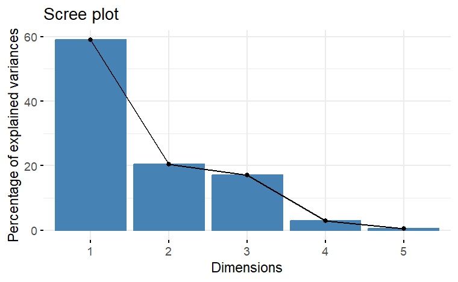

```r
fviz_eig(iris.hillsmith)
```

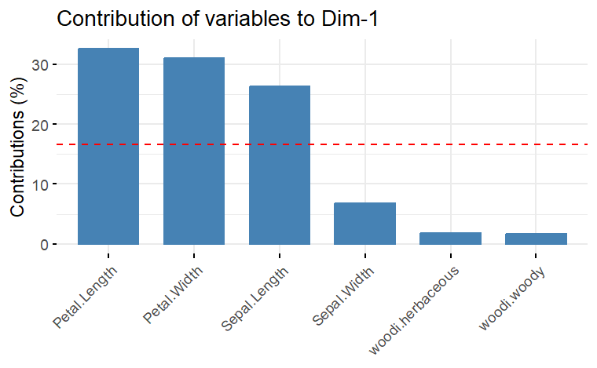

```r
fviz_contrib(iris.hillsmith, "var", 1)
```

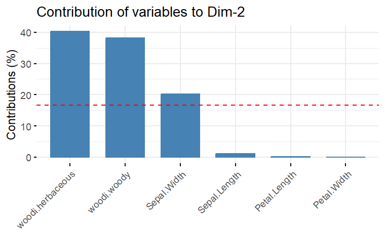

```r
fviz_contrib(iris.hillsmith, "var", 2)
```

# 4 Principle Coordinate Analysis and Non-Metric Multidimensional Scaling

PCoA and NMDS are ordinations that use a distance matrix instead of using the original data. This is particularly useful if you have missing data or data matrices with mixed types of data (ie. numerical and categorical).

NMDS uses the ranked distance between observations rather than the absolute distance values. The algorithm is iterative as it reshuffles the samples in search of the best final distribution in the ordination, so each run may result in a slightly different solution.

Calculating a distance matrix between your different samples can be easily done using the gower distance matrix. The `FD` packages implements a simple and fast function for this called `gowdis`. Let’s use a dummy dataset with different types of data for you to get an idea.

```r
dummy.traits <- FD::dummy$trait

head(dummy.traits)
```

|  | num1 | num2 | fac1 | fac2 | ord1 | ord2 | bin1 | bin2 |
| --- | --- | --- | --- | --- | --- | --- | --- | --- |
| sp1 | 9.0 | 4.5 | A | X | 3 | 2 | 0 | 1 |
| sp2 | 8.1 | 6.0 | A | Z | NA | 1 | 0 | 1 |
| sp3 | NA | 2.3 | C | Y | 5 | 3 | 1 | 1 |
| sp4 | 3.2 | 5.4 | B | Z | 1 | 7 | 0 | 0 |
| sp5 | 5.8 | 1.2 | C | X | 2 | 6 | NA | 0 |
| sp6 | 3.4 | 8.5 | C | Y | 2 | 1 | 1 | 1 |

```r
str(dummy.traits)
```

```
'data.frame':   8 obs. of  8 variables:
 $ num1: num  9 8.1 NA 3.2 5.8 3.4 7.5 4.3
 $ num2: num  4.5 6 2.3 5.4 1.2 8.5 2.1 6.5
 $ fac1: Factor w/ 3 levels "A","B","C": 1 1 3 2 3 3 2 NA
 $ fac2: Factor w/ 3 levels "X","Y","Z": 1 3 2 3 1 2 1 3
 $ ord1: Ord.factor w/ 4 levels "1"<"2"<"3"<"5": 3 NA 4 1 2 2 3 1
 $ ord2: Ord.factor w/ 5 levels "1"<"2"<"3"<"6"<..: 2 1 3 5 4 1 2 3
 $ bin1: int  0 0 1 0 NA 1 1 0
 $ bin2: int  1 1 1 0 0 1 0 1
```

```r
paste("Number of missing values:", sum(is.na(dummy.traits)))
```

```
[1] "Number of missing values: 4"
```

You can see we have an 8 x 8 matrix with different types of variables and some missing data.

Now we will build the distance matrix using gower’s distance.

```r
dist.test <- gowdis(dummy.traits) # Note you can also use the daisy() function from the `cluster` package

class(dist.test)
```

```
[1] "dist"
```

```r
as.matrix(dist.test)
```

```
          sp1       sp2       sp3       sp4       sp5
sp1 0.0000000 0.2181884 0.5240052 0.6737443 0.5291113
sp2 0.2181884 0.0000000 0.6678082 0.5610028 0.8145699
sp3 0.5240052 0.6678082 0.0000000 0.8225701 0.4862253
sp4 0.6737443 0.5610028 0.8225701 0.0000000 0.4843264
sp5 0.5291113 0.8145699 0.4862253 0.4843264 0.0000000
sp6 0.6100161 0.5932587 0.2784736 0.7073925 0.6067323
sp7 0.4484235 0.6863374 0.4848663 0.5575126 0.3023416
sp8 0.4072834 0.2039443 0.5958904 0.2390962 0.5585525
          sp6       sp7       sp8
sp1 0.6100161 0.4484235 0.4072834
sp2 0.5932587 0.6863374 0.2039443
sp3 0.2784736 0.4848663 0.5958904
sp4 0.7073925 0.5575126 0.2390962
sp5 0.6067323 0.3023416 0.5585525
sp6 0.0000000 0.6187844 0.4470207
sp7 0.6187844 0.0000000 0.7030186
sp8 0.4470207 0.7030186 0.0000000
```

Great, now it’s time to perform the PCoA

```r
pcoa.test <- pcoa(dist.test, correction = "cailliez") # note here I am adding the argument correction = "cailliez" to correct for negative eigenvalues

class(pcoa.test)
```

```
[1] "pcoa"
```

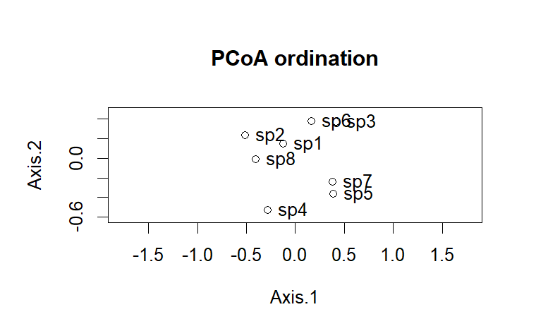

```r
biplot.pcoa(pcoa.test)
```

We can extract the % variance explained by each axis from the `$values` dataframe. Check out the `Rel_corr_eig` and the `Cum_corr_eig` columns.

```r
pcoa.test$values
```

|  | Eigenvalues | Corr_eig | Rel_corr_eig | Broken_stick | Cum_corr_eig | Cum_br_stick |
| --- | --- | --- | --- | --- | --- | --- |
| 1 | 0.516014470 | 1.01918452 | 0.36223254 | 0.40833333 | 0.3622325 | 0.4083333 |
| 2 | 0.411086069 | 0.82624226 | 0.29365815 | 0.24166667 | 0.6558907 | 0.6500000 |
| 3 | 0.250211212 | 0.58079626 | 0.20642318 | 0.15833333 | 0.8623139 | 0.8083333 |
| 4 | 0.071992107 | 0.24096232 | 0.08564140 | 0.10277778 | 0.9479553 | 0.9111111 |
| 5 | 0.000000000 | 0.13003821 | 0.04621741 | 0.06111111 | 0.9941727 | 0.9722222 |
| 6 | -0.006720081 | 0.01639586 | 0.00582732 | 0.02777778 | 1.0000000 | 1.0000000 |
| 7 | -0.074215015 | 0.00000000 | 0.00000000 | 0.00000000 | 1.0000000 | 1.0000000 |
| 8 | -0.091345549 | 0.00000000 | 0.00000000 | 0.00000000 | 1.0000000 | 1.0000000 |

So the first axis explains 36.2% variance and the second explains 29.4% variance, which gives us a cumulative 65.5% variance explained by these 2 axes. Not bad!

Now let’s try with the NMDS

```r
set.seed(12345)
NMDS <- metaMDS(dist.test, k = 2)
```

```
*** Best solution repeated 2 times
```

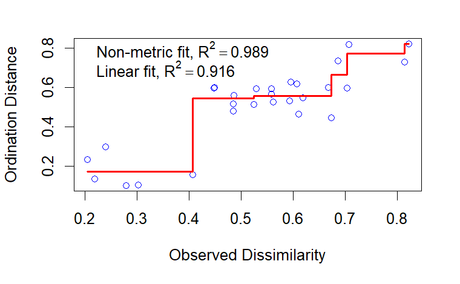

```r
stressplot(NMDS)
```

```
species scores not available
```

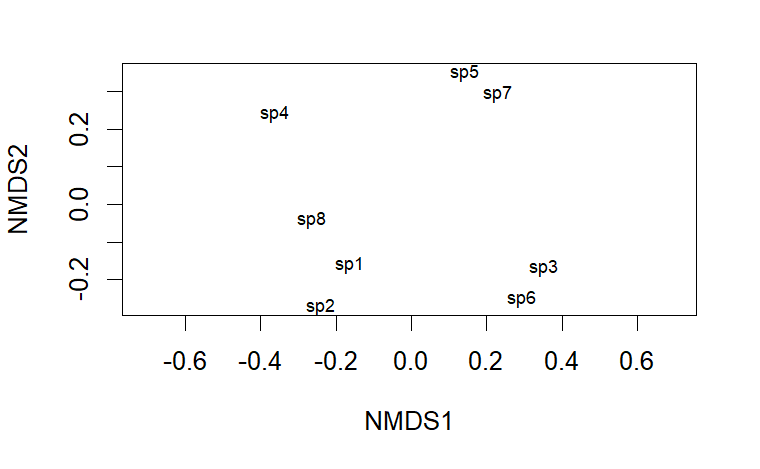

```r
plot(NMDS, type = "t")
```

In this case, both methods show the same patterns: we might have 4 groups in our data, species 8, 1 and 2 group together, species 3 and 6 group together, species 5 and 7 group together and species 4 is slightly outside the rest.

# 5 Clustering

The next useful technique we can use is called clustering. This is basically a method used to assemble all our observations into “natural” groups.

Clustering comes in two flavours:

- *Partitional* (ex: k-means, k-medoids/pam, clara)
- *Hierarchical* (ex: ward, UPGMA, complete-linkage)

Partitional clustering can be represented by plotting the data with an ordination (just like the PCA we made earlier) whilst hierachical clustering is best represented by a tree-like object, called a dendrogram (you can also use an ordination to represent the outcome of a hierarchical clustering if you want)

We would like to know how many clusters (or species in our case) there are in this dataset. There are many different ways to calculate the number of clusters (denoted k), and it is sometimes very subjective to decide which one is best.

Most researchers will typically try different algorithms and assess their performance before choosing the one that best fits the data (or their story for that matter). Typically the “silhouette width” or “within sum of squares” (wss) is quite common to assess the performance.

One nice package to look into this is `NbClust`.

`NbClust` allows us to compute multiple indices to assess the score of our algorithm. for more info, check out the instructions for this package [here](https://www.rdocumentation.org/packages/NbClust/versions/3.0.1/topics/NbClust).

First, let’s try using a partitional framework with the k-means algorithm.

```
*** : The Hubert index is a graphical method of determining the number of clusters.
                In the plot of Hubert index, we seek a significant knee that corresponds to a
                significant increase of the value of the measure i.e the significant peak in Hubert
                index second differences plot.
```

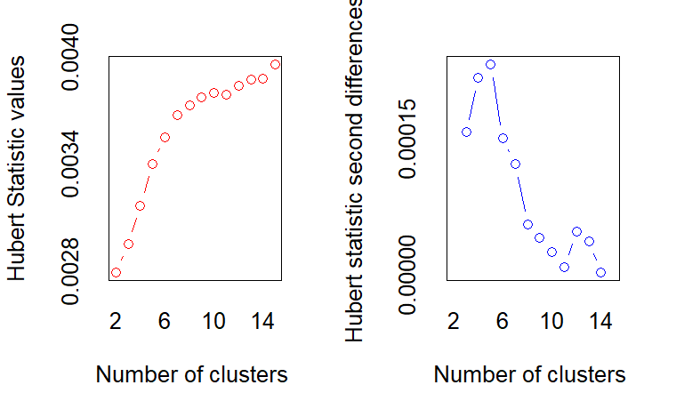

```
*** : The D index is a graphical method of determining the number of clusters.
                In the plot of D index, we seek a significant knee (the significant peak in Dindex
                second differences plot) that corresponds to a significant increase of the value of
                the measure.

* Among all indices:
* 10 proposed 2 as the best number of clusters
* 6 proposed 3 as the best number of clusters
* 1 proposed 4 as the best number of clusters
* 1 proposed 5 as the best number of clusters
* 3 proposed 12 as the best number of clusters
* 1 proposed 14 as the best number of clusters
* 2 proposed 15 as the best number of clusters

                   ***** Conclusion *****

* According to the majority rule, the best number of clusters is  2
```

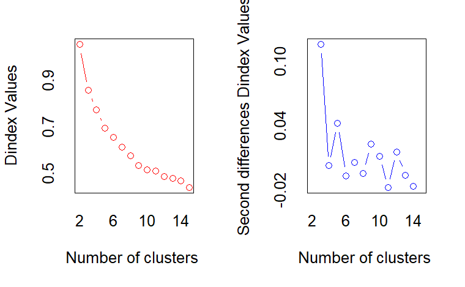

```r
library(NbClust)

clust.iris <- NbClust(scaled.iris[,-5], method = "kmeans")
```

The output is quite lengthy, but basically this is telling us that among multiple indices for calculating the best number of clusters, it seems like k=2 is the most frequent best solutions.

The function also provides us with the assignments that we can plot back onto our data.

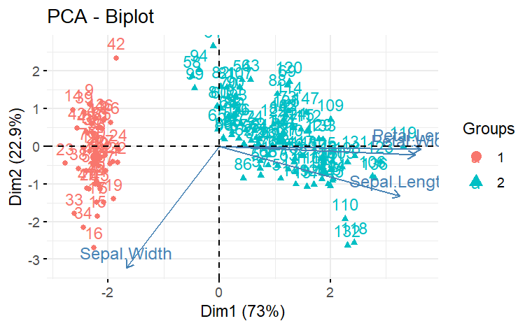

```r
# Create a new object with the assignements provided by the nbclust function
iris2 <- iris %>% mutate(nbclust = clust.iris$Best.partition)

# Now visuzalize it
fviz_pca(pca.iris, habillage=iris2$nbclust)
```

Interesting. We can see our two large groups and maybe a couple of outliers. Let see what the k-means algorithm does when we tell it manually to find 3 clusters

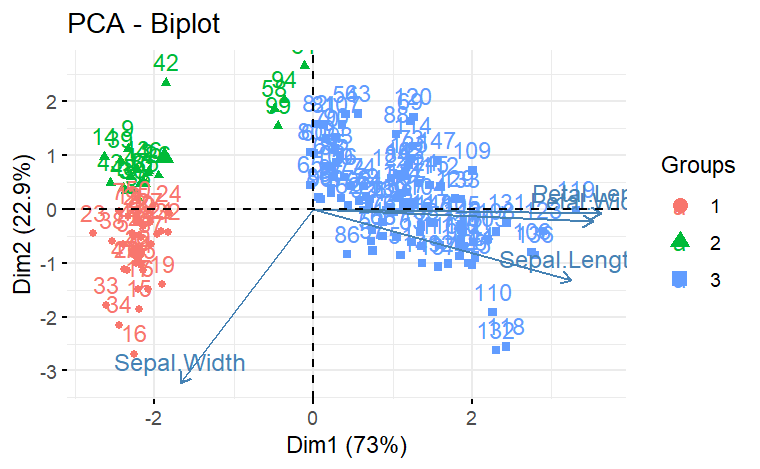

```r
k3.iris <- kmeans(x = scaled.iris[,-5], centers = 3)

iris2$k3 <- k3.iris$cluster

fviz_pca(pca.iris, habillage=iris2$k3)
```

Try to compare with the first PCA plot you made using the `Species` label. Can you see any differences?

Let’s check how our k-means algorithm performs when compared to the original species assignments. This is called a “confusion matrix”.

```r
iris2 %>% dplyr::select(Species, k3) %>% table()
```

```
            k3
Species       1  2  3
  setosa     33 17  0
  versicolor  0  4 46
  virginica   0  0 50
```

What if we look at a different algorithm, this time using a hierarchical framework with Ward’s algorithm.

```
*** : The Hubert index is a graphical method of determining the number of clusters.
                In the plot of Hubert index, we seek a significant knee that corresponds to a
                significant increase of the value of the measure i.e the significant peak in Hubert
                index second differences plot.
```

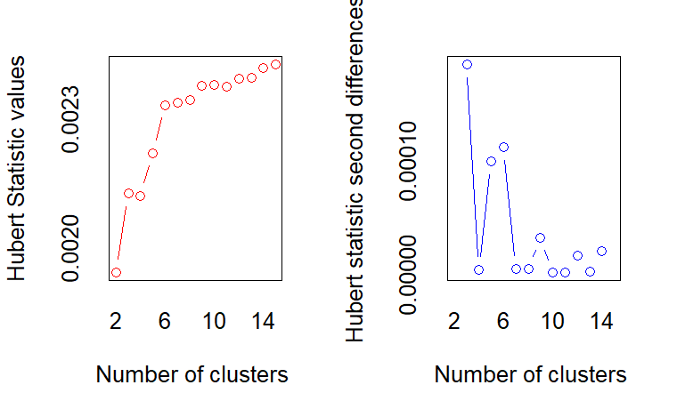

```
*** : The D index is a graphical method of determining the number of clusters.
                In the plot of D index, we seek a significant knee (the significant peak in Dindex
                second differences plot) that corresponds to a significant increase of the value of
                the measure.

* Among all indices:
* 9 proposed 2 as the best number of clusters
* 10 proposed 3 as the best number of clusters
* 3 proposed 6 as the best number of clusters
* 1 proposed 10 as the best number of clusters
* 1 proposed 15 as the best number of clusters

                   ***** Conclusion *****

* According to the majority rule, the best number of clusters is  3
```

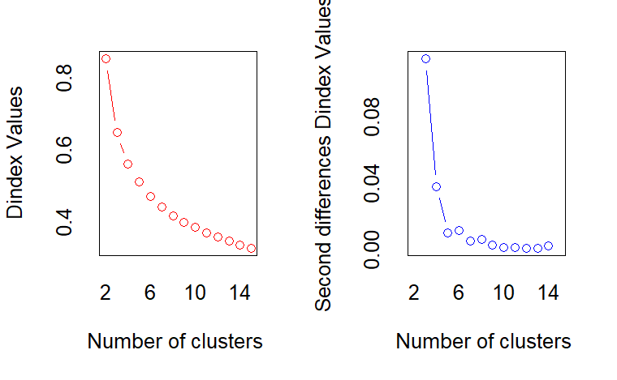

```r
# Note here I am not using the scaled data
# Try using scaled.iris instead and see what happens
hclust.iris <- NbClust(iris[,-5], method = "ward.D")
```

We see that when using Ward’s algorithm, the best number of clusters appears to be 3.

What is the overall performance?

```r
iris2$hclust <- hclust.iris$Best.partition
iris2 %>% dplyr::select(Species, hclust) %>% table()
```

```
            hclust
Species       1  2  3
  setosa     50  0  0
  versicolor  0 50  0
  virginica   0 14 36
```

We can see that the clustering algorithm got all the *I.setosa* species correctly (they were quite obvious), all the *I.versicolor* species correctly, but for *I.virginica*, the algorithm split it up between cluster 2 and 3.

# 6 Dendrograms

Hierachical clustering is nice to visualize using a tree-like object called a dendrogram.

I borrowed the next piece of code from a cool vignette with the `dendextend` package [here](https://cran.r-project.org/web/packages/dendextend/vignettes/Cluster_Analysis.html)

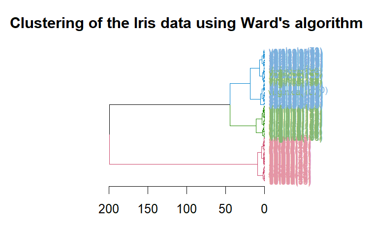

```r
iris_species <- levels(iris[,5])
# recreate the hierarchical cluster
hclust.iris <- hclust(dist(iris[,-5]), method = "ward.D")

dend <- as.dendrogram(hclust.iris)

# Color the branches based on the clusters:
dend <- color_branches(dend, k=3) #, groupLabels=iris_species)

# Manually match the labels, as much as possible, to the real classification of the flowers:
labels_colors(dend) <-
   rainbow_hcl(3)[sort_levels_values(
      as.numeric(iris[,5])[order.dendrogram(dend)]
   )]

# We shall add the flower type to the labels:
labels(dend) <- paste(as.character(iris[,5])[order.dendrogram(dend)],
                           "(",labels(dend),")",
                           sep = "")

# We hang the dendrogram a bit:
dend <- hang.dendrogram(dend,hang_height=0.1)

# reduce the size of the labels:
dend <- assign_values_to_leaves_nodePar(dend, 0.5, "lab.cex")
dend <- set(dend, "labels_cex", 0.7)

# And plot:
par(mar = c(3,7,3,7))
plot(dend,
     main = "Clustering of the Iris data using Ward's algorithm",
     horiz =  TRUE)
```

# 7 Additional ressources

There are plenty of website out there with tutorials on how to perform different tasks in R.

Some of my favourites include

- Alboukadel Kassambara and his excellent [STHDA](http://www.sthda.com/english/) and [Datanovia](https://www.datanovia.com/en/blog/types-of-clustering-methods-overview-and-quick-start-r-code/) websites
- This website from the [Quebec Centre for Biodiversity Science](https://r.qcbs.ca/workshops/) which is slightly more orientated towards community ecology but the same principles apply.
- [David Zeleny’s website](https://www.davidzeleny.net/anadat-r/doku.php/en:start) on community ecology is fantastic.
- And also the excelent [Our Coding Club](https://ourcodingclub.github.io/tutorials) with tutorials on just about anything in R.